# By way of introduction…

# Changing options in ggplot2

`ggplot` handles options in additional layers.

### Labels

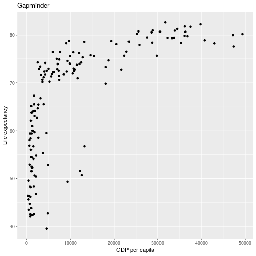

```r
ggplot(data = gap2007, aes(x = gdpPercap, y = lifeExp)) + geom_point() +
  xlab(label = "GDP per capita") +
  ylab(label = "Life expectancy") +
  ggtitle(label = "Gapminder")
```

### Axis and point scales

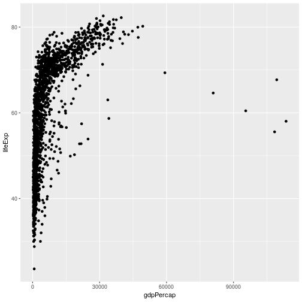

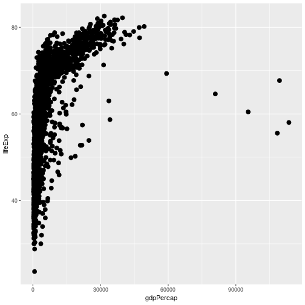

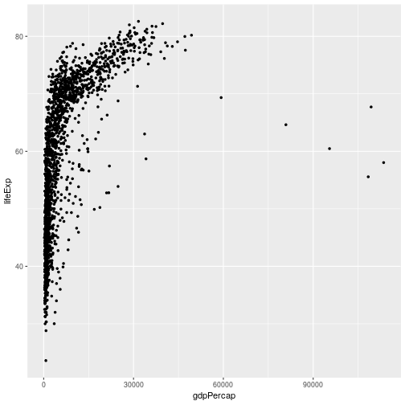

```r
ggplot(data = gap, aes(x = gdpPercap, y = lifeExp)) +
            geom_point()
ggplot(data = gap, aes(x = gdpPercap, y = lifeExp)) +
            geom_point(size=3)
ggplot(data = gap, aes(x = gdpPercap, y = lifeExp)) +
            geom_point(size=1)
```

### Colors

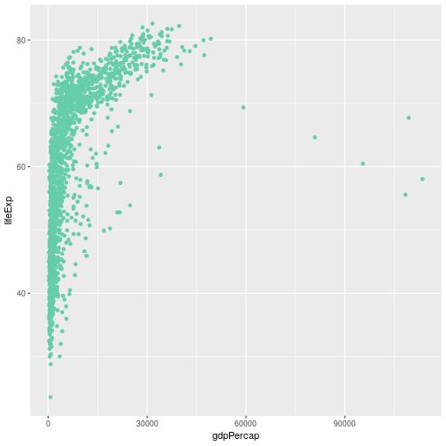

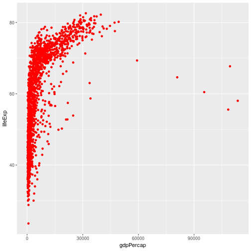

```r
ggplot(data = gap, aes(x = gdpPercap, y = lifeExp)) +
            geom_point(color = colors()[11])
ggplot(data = gap, aes(x = gdpPercap, y = lifeExp)) +
            geom_point(color = "red")
```

### Point Styles and Widths

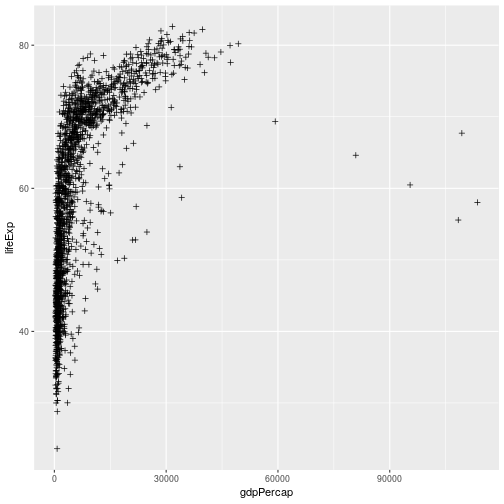

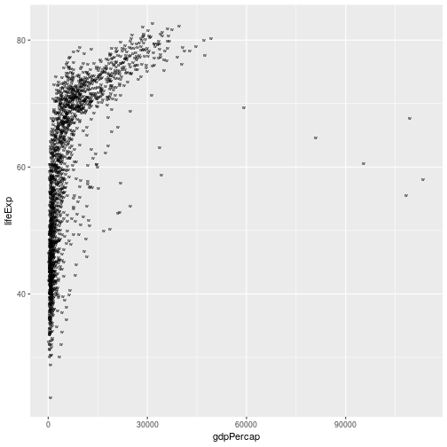

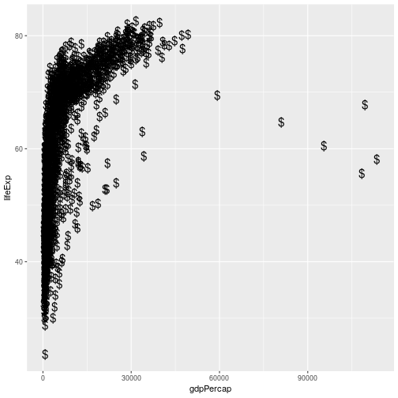

```r
ggplot(data = gap, aes(x = gdpPercap, y = lifeExp)) +
            geom_point(shape = 3)
ggplot(data = gap, aes(x = gdpPercap, y = lifeExp)) +
            geom_point(shape = "w")
ggplot(data = gap, aes(x = gdpPercap, y = lifeExp)) +
            geom_point(shape = "$", size=5)
```

### Line Styles and Widths

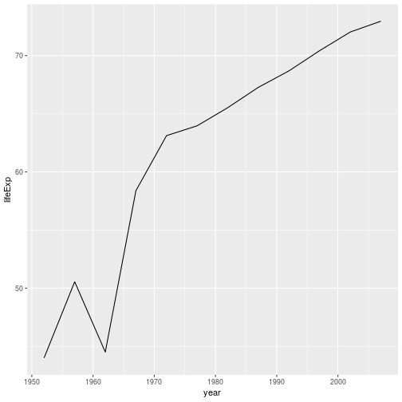

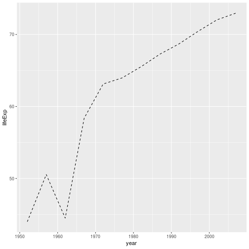

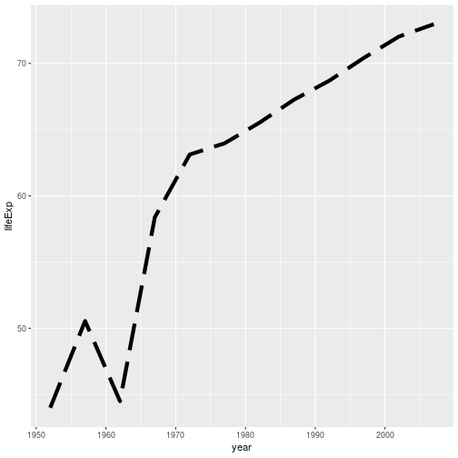

```r
ggplot(data = gapChina, aes(x = year, y = lifeExp)) +
            geom_line(linetype = 1)
ggplot(data = gapChina, aes(x = year, y = lifeExp)) +
            geom_line(linetype = 2)
ggplot(data = gapChina, aes(x = year, y = lifeExp)) +
            geom_line(linetype = 5, size = 2)
```

# Fitted lines and curves with `ggplot2`

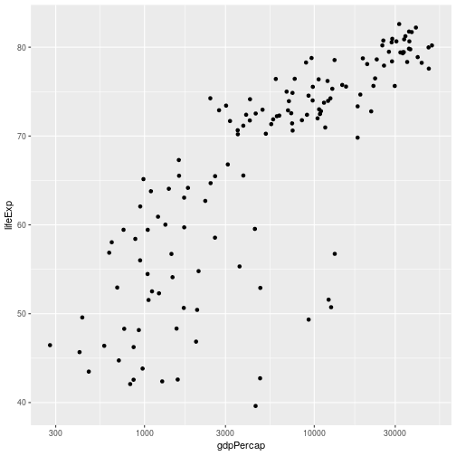

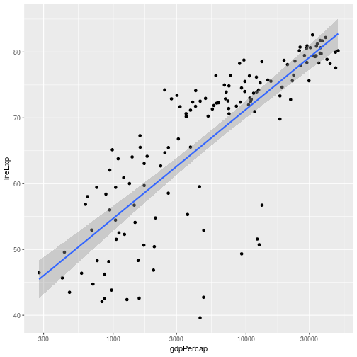

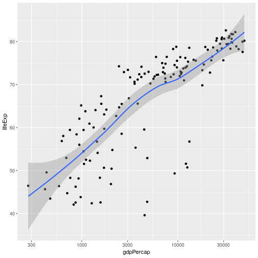

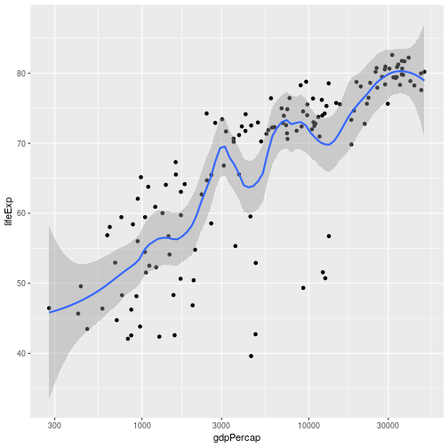

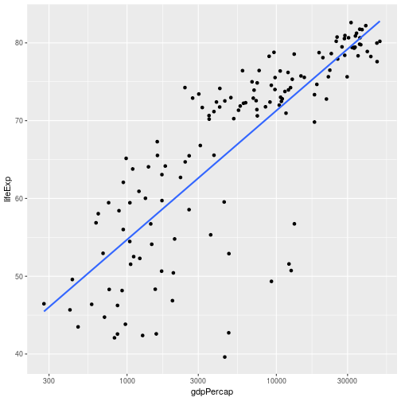

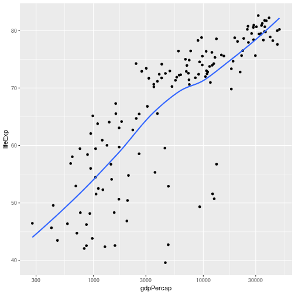

```r
ggplot(data = gap2007, aes(x = gdpPercap, y = lifeExp)) + geom_point() + scale_x_log10()

# Add linear model (lm) smoother
ggplot(data = gap2007, aes(x = gdpPercap, y = lifeExp)) + geom_point() + scale_x_log10() +
  geom_smooth(method = "lm")

# Add local linear model (loess) smoother, span of 0.75 (more smoothed)
ggplot(data = gap2007, aes(x = gdpPercap, y = lifeExp)) + geom_point() + scale_x_log10() +
  geom_smooth(method = "loess", span = .75)

# Add local linear model (loess) smoother, span of 0.25 (less smoothed)
ggplot(data = gap2007, aes(x = gdpPercap, y = lifeExp)) + geom_point() + scale_x_log10() +
  geom_smooth(method = "loess", span = .25)

# Add linear model (lm) smoother, no standard error shading
ggplot(data = gap2007, aes(x = gdpPercap, y = lifeExp)) + geom_point() + scale_x_log10() +
  geom_smooth(method = "lm", se = FALSE)

# Add local linear model (loess) smoother, no standard error shading
ggplot(data = gap2007, aes(x = gdpPercap, y = lifeExp)) + geom_point() + scale_x_log10() +
  geom_smooth(method = "loess", se = FALSE)
```

# Combining Multiple Plots

- `ggplot2` graphs can be combined using the *`grid.arrange()`* function in the **`gridExtra`** package

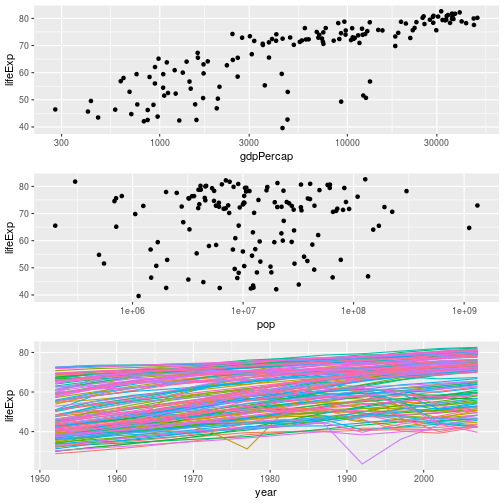

```r
# Initialize gridExtra library
library(gridExtra)

# Create 3 plots to combine in a table
plot1 <- ggplot(data = gap2007, aes(x = gdpPercap, y = lifeExp)) +
  geom_point() + scale_x_log10()
plot2 <- ggplot(data = gap2007, aes(x = pop, y = lifeExp)) +
  geom_point() + scale_x_log10()
plot3 <- ggplot(data = gap, aes(x = year, y = lifeExp)) +
      geom_line(aes(color = country), show.legend = FALSE)


# Call grid.arrange
grid.arrange(plot1, plot2, plot3, nrow=3, ncol = 1)
```

# `patchwork`: Combining Multiple `ggplot2` plots

- The `patchwork` package may be used to combine multiple `ggplot2` plots using a small set of operators similar to the pipe.
- This requires less syntax than using `gridExtra` and allows complex arrangements to be built nearly effortlessly.

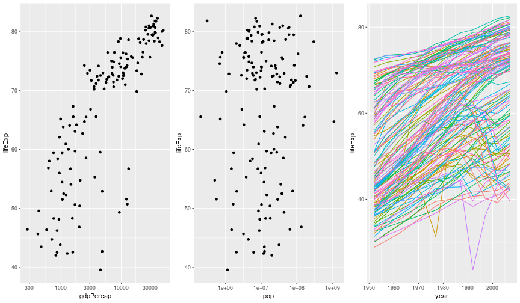

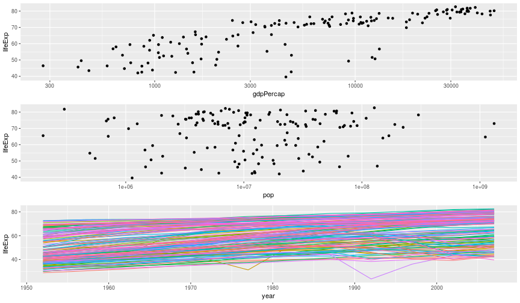

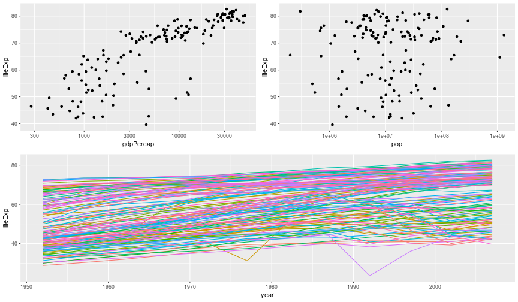

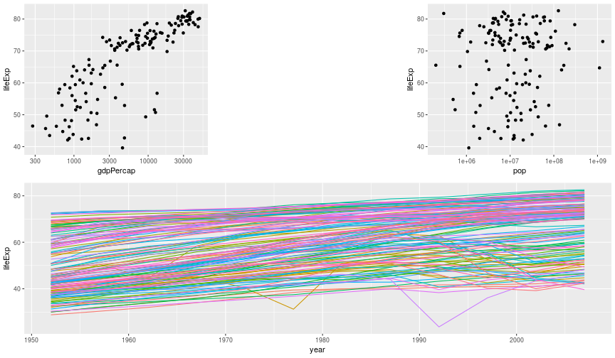

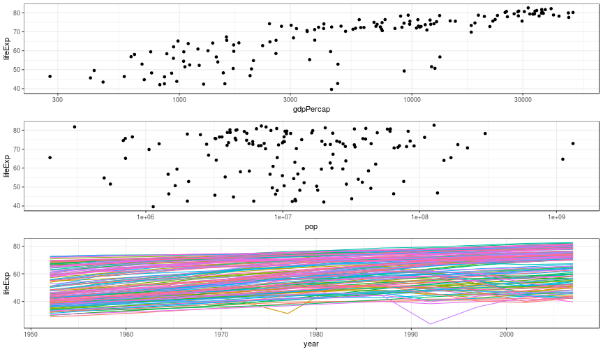

```r
# Install and initialize patchwork library
# devtools::install_github("thomasp85/patchwork")
library(patchwork)

# use the patchwork operators
# stack plots horizontally
plot1 + plot2 + plot3

# stack plots vertically
plot1 / plot2 / plot3

# side-by-side plots with third plot below
(plot1 | plot2) / plot3

# side-by-side plots with a space in between, and a third plot below
(plot1 | plot_spacer() | plot2) / plot3

# stack plots vertically and alter with a single "gg_theme"
(plot1 / plot2 / plot3) & theme_bw()
```

Feel free to explore more at https://github.com/thomasp85/patchwork.

# Exporting

Two basic image types:

### **Raster/Bitmap** (.png, .jpeg)

Every pixel of a plot contains its own separate coding; not so great if you want to resize the image

```r
jpeg(filename = "example.jpg", width=, height=)
plot(x,y)
dev.off()
```

### **Vector** (.pdf, .ps)

Every element of a plot is encoded with a function that gives its coding conditional on several factors; great for resizing

```r
# NOT run
pdf(file = "example.pdf", width=, height=)
plot(x,y)
dev.off()
```

### Exporting with `ggplot`

```r
# NOT run

# Assume we saved our plot is an object called `plot1`.

ggsave(filename = "example.pdf", plot = plot1, scale = , width = ,
       height = )
```

# Breakout

These questions ask you to work with the gapminder dataset.

### Basics

1) Plot a histogram of life expectancy.

2) Plot the gdp per capita against population. Put the x-axis on the log scale.

3) Clean up your scatterplot with a title and axis labels. Output it as a PDF and see if you'd be comfortable with including it in a report/paper.

### Using the ideas

4) Create a trellis plot of life expectancy by gdpPercap scatterplots, one subplot per continent. Use a 2x3 layout of panels in the plot. Now have the size of the points vary with population. Use `scale_x_continuous()` to set the x-axis limits to be in the range from 100 to 50000.

5) Make a boxplot of life expectancy conditional on binned values of gdp per capita.

### Advanced

6) Using the data for 2007, recreate as much as you can of [this famous Gapminder plot](https://s3-eu-west-1.amazonaws.com/static.gapminder.org/GapminderMedia/wp-uploads/20161019161829/screenshot2016.jpg), where the colors are different continents. (Don't worry about the '2015' in the background and ignore the 'play' button at the bottom.)

7) Create a “trellis” plot where, for a given year, each panel uses a) hollow circles to plot lifeExp as a function of log(gdpPercap), and b) a red loess smoother without standard errors to plot the trend. Turn off the grey background. Figure out how to use partially-transparent points to reduce the effect of the overplotting of points.